# Random Projection and the Johnson-Lindenstrauss Lemma

Blum, Hopcroft & Kannan (2020), Section 2.7

Author

Posit Assistant

Published

May 20, 2026

> **About this document.** This is a teaching document prepared by Posit Assistant. It is intended to be read alongside the student’s own `Projection.qmd` and `Projection.R` working files, which are the primary record of their notes and code.

## The Problem

You have $n$ points in $\mathbb{R}^d$ where $d$ is very large — think documents represented as word-count vectors, or images as pixel vectors. High dimensionality is expensive: distances are hard to compute, nearest-neighbor search is slow, and storing the data takes enormous space.

The natural question: can we **map points to a much lower-dimensional space** while approximately preserving all pairwise distances? If we can, everything downstream (clustering, similarity search, classification) becomes cheaper, without meaningfully degrading quality.

The naive fear is that projection loses information irreparably. The remarkable fact is that **random projection works** — and the target dimension depends only on $n$ and your tolerance for error, not on the original dimension $d$.

## Setup: The Random Projection Map

The map is almost embarrassingly simple. Given $n$ points in $\mathbb{R}^d$, choose a $k \times d$ matrix $A$ whose entries are i.i.d. $\mathcal{N}(0, 1)$, and define:

$$f(x) = \frac{1}{\sqrt{k}}\, A x$$

That’s it. Project each point by multiplying by a random Gaussian matrix and scaling.

**Why Gaussian?** The Gaussian distribution is rotationally symmetric, which means the distribution of $f(x)$ doesn’t depend on the direction of $x$, only its length. This symmetry is what makes the analysis tractable.

**The scaling factor $1/\sqrt{k}$** ensures that $\mathbb{E}\|f(x)\|^2 = \|x\|^2$. Each coordinate of $Ax/\sqrt{k}$ has mean 0 and variance $\|x\|^2/k$, and summing $k$ such coordinates gives an expected squared norm of $\|x\|^2$.

## Concentration of Measure: One Vector

Before proving anything about $n$ points, we need to understand what happens to a **single vector** $v \in \mathbb{R}^d$ under random projection.

Let $r_1, \ldots, r_k$ be the rows of $A$ (each an independent random vector in $\mathbb{R}^d$ with i.i.d. $\mathcal{N}(0,1)$ entries). Then:

$$\|f(v)\|^2 = \frac{1}{k} \sum_{i=1}^{k} (r_i \cdot v)^2$$

Each term $r_i \cdot v \sim \mathcal{N}(0, \|v\|^2)$, so $(r_i \cdot v)^2 / \|v\|^2 \sim \chi^2(1)$. The sum $\|f(v)\|^2 / \|v\|^2$ is therefore $\frac{1}{k}$ times a $\chi^2(k)$ random variable.

The mean of this quantity is 1. The question is whether it **concentrates** tightly around 1. It does — and this is precisely the kind of exponential concentration result established earlier in Chapter 2 (Theorem 2.5).

**NoteKey concentration bound**

For any fixed unit vector $v$ and $0 < \varepsilon < 1$:

$$P\!\left(\left|\,\|f(v)\|^2 - 1\,\right| > \varepsilon\right)
\;\leq\; 2\, e^{-(\varepsilon^2 - \varepsilon^3)\,k/4}$$

For small $\varepsilon$ this simplifies to approximately $2e^{-\varepsilon^2 k / 4}$. The probability of bad distortion decays **exponentially** in $k$.

## The Johnson-Lindenstrauss Lemma

**ImportantJohnson-Lindenstrauss Lemma**

For any $0 < \varepsilon < 1$ and any $n$ points $x_1, \ldots, x_n \in \mathbb{R}^d$, the random map $f(x) = \frac{1}{\sqrt{k}} Ax$ with

$$k = O\!\left(\frac{\log n}{\varepsilon^2}\right)$$

satisfies, with positive probability, for **all pairs** $i \neq j$:

$$(1 - \varepsilon)\,\|x_i - x_j\|^2
\;\leq\;
\|f(x_i) - f(x_j)\|^2
\;\leq\;
(1 + \varepsilon)\,\|x_i - x_j\|^2$$

Three things to notice immediately:

1. **$k$ does not depend on $d$.** No matter how high-dimensional the original space, you can project to the same target dimension.
2. **$k$ grows only logarithmically in $n$.** One million points requires roughly twice the dimensions as one thousand points.
3. The map is **random** — no clever structure required, just noise.

## Proof Outline: Union Bound Over All Pairs

The proof assembles the concentration bound with a counting argument.

**Step 1.** Apply linearity. Distance preservation between $x_i$ and $x_j$ is equivalent to norm preservation of the difference vector $v = x_i - x_j$, since $f$ is linear: $f(x_i) - f(x_j) = f(x_i - x_j)$.

**Step 2.** Fix any one pair. By the concentration bound above:

$$P\!\left(\text{pair } (i,j) \text{ is badly distorted}\right) \leq 2\, e^{-\varepsilon^2 k / 4}$$

**Step 3.** There are $\binom{n}{2}$ pairs. By the union bound, the probability that **any** pair is badly distorted is at most:

$$\binom{n}{2} \cdot 2\, e^{-\varepsilon^2 k / 4}
\;<\;
n^2\, e^{-\varepsilon^2 k / 4}$$

**Step 4.** Set this less than 1 (guaranteeing existence of a good projection) and solve for $k$:

$$n^2\, e^{-\varepsilon^2 k / 4} < 1
\;\implies\;
k > \frac{8 \log n}{\varepsilon^2}$$

That’s $k = O(\log n / \varepsilon^2)$. $\square$

**TipThe key move**

The proof uses randomness in a subtle way: we don’t find a good projection explicitly — we show that a random one works with **positive probability**. That’s enough to guarantee one exists. This “probabilistic method” argument recurs throughout the book.

## Simulation 1: Distance Preservation

The lemma says projected distances are close to original distances. Let’s verify directly. We generate 150 random points in $\mathbb{R}^{1000}$, project to $\mathbb{R}^{50}$, then compare all $\binom{150}{2} = 11{,}175$ pairwise distances.

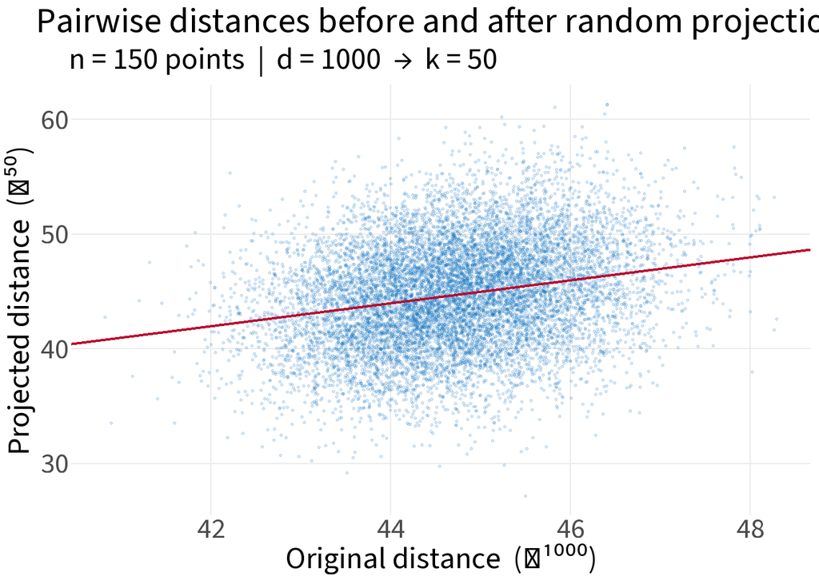

Figure 1: Each point is a pair of observations. Perfect preservation would place all points on the red diagonal. Spread around the line reflects distortion from projecting to 50 dimensions.

```r
set.seed(3847)
n <- 150; d <- 1000; k <- 50

X      <- matrix(rnorm(n * d), nrow = n)
A      <- matrix(rnorm(k * d), nrow = k) / sqrt(k)
X_proj <- X %*% t(A)

tibble(
  original  = as.vector(dist(X)),
  projected = as.vector(dist(X_proj))
) |>
  ggplot(aes(x = original, y = projected)) +
  geom_point(alpha = 0.15, size = 0.6, color = medium_blue) +
  geom_abline(slope = 1, intercept = 0, color = usaid_red, linewidth = 0.8) +
  labs(
    title    = "Pairwise distances before and after random projection",
    subtitle = glue::glue("n = {n} points  |  d = {d}  →  k = {k}"),
    x        = "Original distance  (ℝ¹⁰⁰⁰)",
    y        = "Projected distance  (ℝ⁵⁰)"
  )
```

## Simulation 2: Effect of $k$ on Distortion

The lemma says distortion shrinks as $k$ grows. We measure this with the **maximum distortion** across all pairs:

$$\Delta_k = \max_{i \neq j} \left|\frac{\|f(x_i) - f(x_j)\|^2}{\|x_i - x_j\|^2} - 1\right|$$

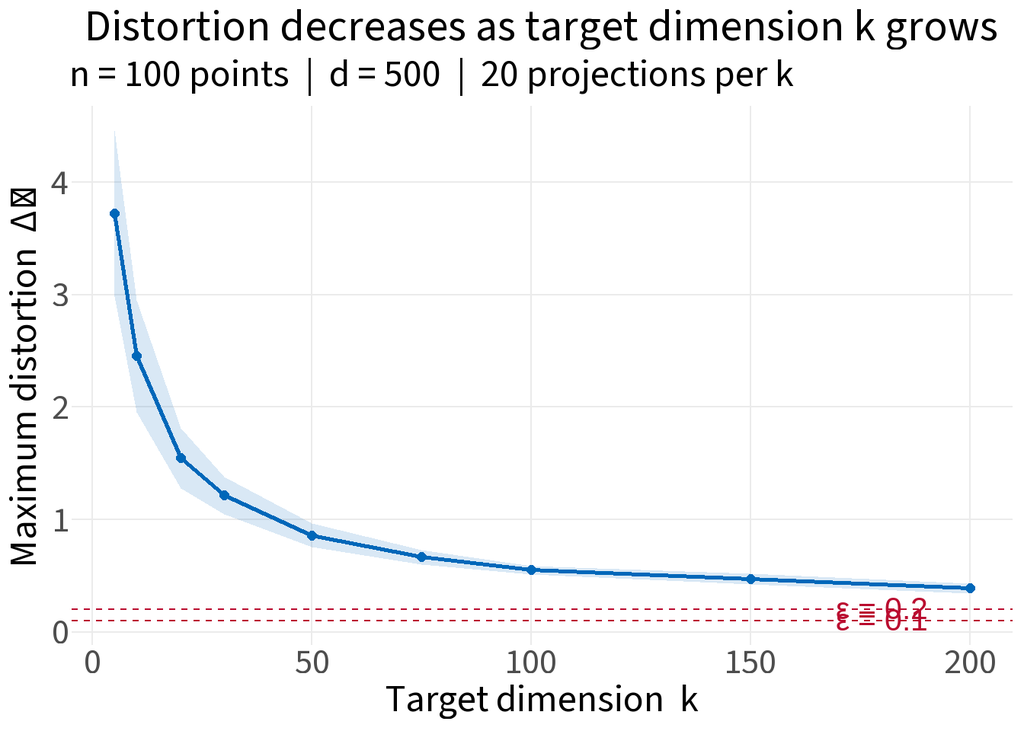

Figure 2: Maximum distortion across all pairwise distances as a function of target dimension k. Dashed lines mark ε = 0.1 and ε = 0.2. Points are means over 20 random projections; ribbon shows ±1 SD.

```r
set.seed(9201)
n <- 100; d <- 500
ks <- c(5, 10, 20, 30, 50, 75, 100, 150, 200)
reps <- 20

X      <- matrix(rnorm(n * d), nrow = n)
d_orig <- as.vector(dist(X))

map_dfr(ks, \(k)
  map_dfr(seq_len(reps), \(rep) {
    d_proj <- as.vector(dist(X %*% t(matrix(rnorm(k * d), nrow = k) / sqrt(k))))
    tibble(k = k, max_distortion = max(abs(d_proj^2 / d_orig^2 - 1)))
  })
) |>
  summarise(mu = mean(max_distortion), sd = sd(max_distortion), .by = k) |>
  ggplot(aes(x = k, y = mu)) +
  geom_ribbon(aes(ymin = mu - sd, ymax = mu + sd), fill = medium_blue, alpha = 0.15) +
  geom_line(color = medium_blue, linewidth = 0.9) +
  geom_point(color = medium_blue, size = 2) +
  geom_hline(yintercept = c(0.1, 0.2), linetype = "dashed",
             color = usaid_red, linewidth = 0.5) +
  annotate("text", x = max(ks) * 0.95, y = 0.115,
           label = "ε = 0.1", color = usaid_red, hjust = 1, size = 3.5) +
  annotate("text", x = max(ks) * 0.95, y = 0.215,
           label = "ε = 0.2", color = usaid_red, hjust = 1, size = 3.5) +
  labs(
    title    = "Distortion decreases as target dimension k grows",
    subtitle = glue::glue("n = {n} points  |  d = {d}  |  {reps} projections per k"),
    x = "Target dimension  k",
    y = "Maximum distortion  Δₖ"
  )
```

## Simulation 3: $k$ Is Independent of $d$

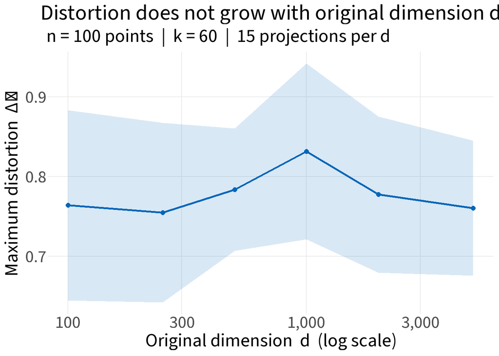

Figure 3: Maximum distortion at a fixed k = 60, across a range of original dimensions d (log scale). The flat trend confirms that distortion depends on n and k only — not on d.

```r
set.seed(5513)
n <- 100; k <- 60
ds <- c(100, 250, 500, 1000, 2000, 5000)
reps <- 15

map_dfr(ds, \(d)
  map_dfr(seq_len(reps), \(rep) {
    X      <- matrix(rnorm(n * d), nrow = n)
    d_orig <- as.vector(dist(X))
    d_proj <- as.vector(dist(X %*% t(matrix(rnorm(k * d), nrow = k) / sqrt(k))))
    tibble(d = d, max_distortion = max(abs(d_proj^2 / d_orig^2 - 1)))
  })
) |>
  summarise(mu = mean(max_distortion), sd = sd(max_distortion), .by = d) |>
  ggplot(aes(x = d, y = mu)) +
  geom_ribbon(aes(ymin = mu - sd, ymax = mu + sd), fill = medium_blue, alpha = 0.15) +
  geom_line(color = medium_blue, linewidth = 0.9) +
  geom_point(color = medium_blue, size = 2) +
  scale_x_log10(labels = scales::comma) +
  labs(
    title    = "Distortion does not grow with original dimension d",
    subtitle = glue::glue("n = {n} points  |  k = {k}  |  {reps} projections per d"),
    x = "Original dimension  d  (log scale)",
    y = "Maximum distortion  Δₖ"
  )
```

## Summary

| Concept | Key point |
| --- | --- |
| **Random projection map** | $f(x) = \frac{1}{\sqrt{k}} Ax$, $A$ with i.i.d. $\mathcal{N}(0,1)$ entries |
| **Why it works** | Gaussian concentration: projected lengths are tightly concentrated around their expectation |
| **JL Lemma** | $k = O(\log n / \varepsilon^2)$ suffices to preserve all $\binom{n}{2}$ pairwise distances within $(1 \pm \varepsilon)$ |
| **Key surprise** | $k$ is independent of original dimension $d$ |
| **Proof technique** | Concentration bound on one pair + union bound over all $\binom{n}{2}$ pairs |

The Johnson-Lindenstrauss Lemma is not just a theoretical curiosity — it underlies dimensionality reduction in large-scale machine learning, locality-sensitive hashing, and compressed sensing. The same random projection idea recurs throughout the rest of the book.